# ggparliament: Parliament Plots in the Tidyverse

20 June, 2018

## Uh… What are parliament plots? 😕

- They are visual representations of the composition of legislatures.
- Parliament plots often display seats color-coded by party
- This is one the first attempts at creating an `R` package for parliament plots

## ggparliament

- ggparliament was first started by Thomas Leeper
- Rob Hickman and I have taken over the package
- The idea is that it creates `ggplot2` objects of parliamentary seats that integrate seamlessly with other `tidyverse` packages
- Currently working on the development version of the package
  - ggparliament is not on CRAN
  - We can plot several parliament styles ranging from the horseshoe parliament (like the one we have here!) or two opposing benches (like the in UK)

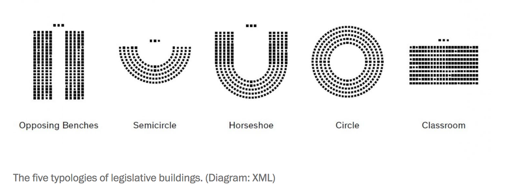

David Mulder Van der Vegt and Max Cohen de Lara, 2017, These 5 architectural designs influence every legislature in the world – and tell you how each governs, March 4, The Washington Post

## Great…😄 How can we use it?

- Start with aggregate election results.
- We include data from several countries several in the package.
- For example, I will look at the Australian 2016 election.
- The data frame looks like this …

```r
library(ggparliament)
australia <- election_data %>% # the data we have included is in election_data
  filter(year == 2016 &  # filter for country, year, and legislative chamber
           country == "Australia" &
           house == "Representatives")
head(australia)
```

|  | year | country | house | party_long | party_short | seats | government | colour |
| --- | --- | --- | --- | --- | --- | --- | --- | --- |
| 1 | 2016 | Australia | Representatives | Labour | Lab | 69 | NA | #F00011 |
| 2 | 2016 | Australia | Representatives | Liberal | Lib | 45 | 1 | #080CAB |
| 3 | 2016 | Australia | Representatives | Liberal National | LNP | 21 | 1 | #1456F1 |
| 4 | 2016 | Australia | Representatives | National | Nat | 10 | 1 | #008000 |
| 5 | 2016 | Australia | Representatives | Greens | Green | 1 | NA | #10C25B |
| 6 | 2016 | Australia | Representatives | Xenophon Team | Xenophon | 1 | NA | #FF6300 |

## Data munging

- We want to expand the aggregated seats per party into a long list of individual seats and plot the location of each seat on the chart
- We created a function, `parliament_data()`, that will do this for you!

```r
#I am reordering the data to reflect the way the Australian parliament is structured
#(gov't on right, opposition on left) but this isn't strictly neccesary
australia <- australia[c(1, 5, 6, 7, 4, 3, 2), ]
#run your election results through parliament_data()
aus <- parliament_data(election_data = australia, # you need to specify the data frame
                       total_seats = sum(australia$seats), # sum up the total amount of seats
                       party_seats = australia$seats, # number of seats per party
                       parl_rows = 4, # how many rows do we want?
                       type = "horseshoe") # what type of parliament do we want?
head(aus)
```

|  | year | country | house | party_long | party_short | seats | government | colour | x | y | row | theta |
| --- | --- | --- | --- | --- | --- | --- | --- | --- | --- | --- | --- | --- |
| 1 | 2016 | Australia | Representatives | Labour | Lab | 69 | NA | #F00011 | -7.000000 | 8.572528e-16 | 4 | 3.141593 |
| 1.1 | 2016 | Australia | Representatives | Labour | Lab | 69 | NA | #F00011 | -6.500000 | 7.960204e-16 | 3 | 3.141593 |
| 1.2 | 2016 | Australia | Representatives | Labour | Lab | 69 | NA | #F00011 | -6.000000 | 7.347881e-16 | 2 | 3.141593 |
| 1.3 | 2016 | Australia | Representatives | Labour | Lab | 69 | NA | #F00011 | -5.500000 | 6.735557e-16 | 1 | 3.141593 |
| 1.4 | 2016 | Australia | Representatives | Labour | Lab | 69 | NA | #F00011 | -6.978421 | 5.492137e-01 | 4 | 3.063053 |
| 1.5 | 2016 | Australia | Representatives | Labour | Lab | 69 | NA | #F00011 | -6.477799 | 5.367657e-01 | 3 | 3.058919 |

## Now… The fun stuff 😄

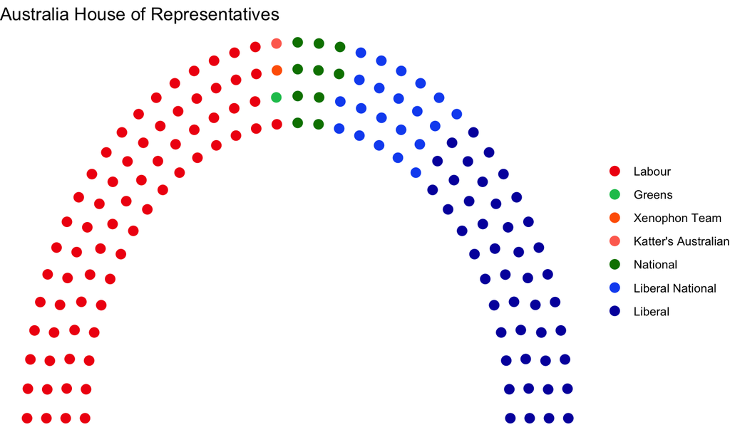

```r
ggplot(aus, aes(x, y, colour=party_long)) + #define the data frame and how you want to colour the circles
  geom_parliament_seats() + # this geom plots the seats
  theme_void() + # we have created a theme for the package but this is optional
  labs(colour = "", title = "Australia House of Representatives") +
  scale_colour_manual(values = aus$colour, limits = aus$party_long)
```

## Cool. What else? - We can highlight certain seats!

- This is a work in progress
- We can add text to the plot as well
- We’re working on ways to break up the seats by faceting.

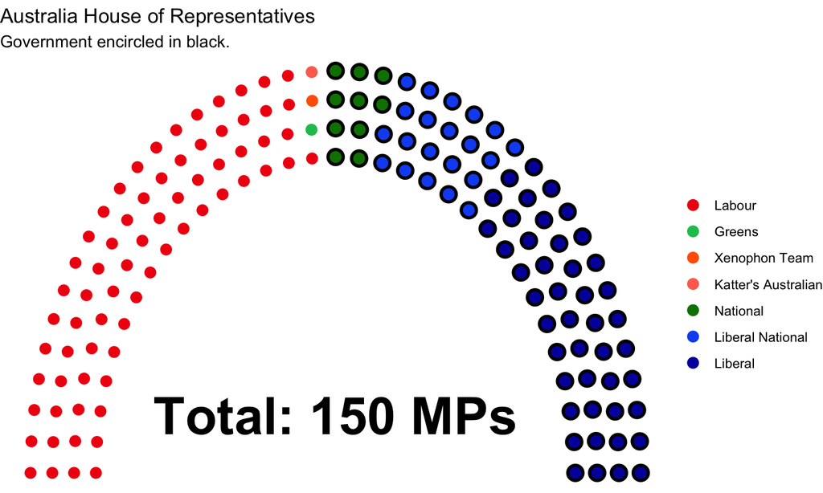

```r
ggplot(aus, aes(x, y, colour=party_long)) +
  geom_parliament_seats() +
  theme_void() +
  geom_highlight_government(government == 1) +
  labs(colour = "", title = "Australia House of Representatives",
  subtitle = "Government encircled in black.") +
  annotate("text", x=0, y=1, label=paste("Total: 150 MPs"), fontface="bold", size=12) +
  scale_colour_manual(values = aus$colour, limits = aus$party_long)
```

### Thank you!

#### Zoe Meers

#### @zoe_meers

#### zoe.meers@sydney.edu.au